# Characteristics-driven returns in equilibrium

This notebook presents the R code used for the paper [“*Characteristics-driven returns in equilibrium*”](https://papers.ssrn.com/sol3/papers.cfm?abstract_id=3941195).  
Only the strict minimum of material is provided.  
The **dataset**, with anonymized firm identifiers, is available [here](https://drive.google.com/file/d/1n29qmIFHXMtJ4OVS-OsdHt5224j8tptP/view?usp=sharing).  
The R Markdown notebook that can be run directly in RStudio is accessible [here](https://drive.google.com/file/d/1yDy3e1Zr2iycJgqDdYiEOt_CfPogwl6u/view?usp=sharing).

# 1 Setup

First, we load packages & import the data.  
The comments, preceded by hashtags # allow to change the **set of characteristics** (e.g., from 3 to 6).  
Below, we work with 6 characteristics, so the results will slightly differ from the original ones in the paper.

```r
library(tidyverse)                                      # Data wrangling package
library(lubridate)                                      # Date management
library(ggallin)                                        # Addin to ggplot for negative log scales
library(viridis)                                        # Cool color palette
library(patchwork)                                      # To layout graphs
library(plm)                                            # For panel model estimation
load("data_demand.RData")                               # Loading the data
data_demand <- data_demand %>% arrange(Stock_id, Date)  # Ordering
dates <- data_demand$Date %>% unique() %>% sort()
features <- c("Mkt_Cap", "P2B", "Mom", "Asset_growth", "Prof_Marg", "Vol_1M")
#features <- c("Mkt_Cap", "P2B", "Mom")
D_features <- c("D_Mkt_Cap", "D_P2B", "D_Mom", "D_Asset_growth", "D_Prof_Marg", "D_Vol_1M")
#D_features <- c("D_Mkt_Cap", "D_P2B", "D_Mom")
```

# 2 Initialization of variables

Below, we create the objects in which we will store some results.  
Also, we fix the **sample size** of rolling windows used throughout the notebook! This is a critical choice.

```r
sample <- 60                                                                       # Sample size (in months)
dates_oos <- dates[sample:length(dates)]                                           # Out-of-sample dates
coefs_1 <- matrix(nrow = length(dates_oos) - 1, ncol = 2 * length(features) + 1)   # Initialize coefficients
t_stats_1 <- matrix(nrow = length(dates_oos) - 1, ncol = 2 * length(features) + 1) # Initialize t-statistics
R_1_pool <- matrix(0, ncol = 2, nrow = length(dates_oos) - 1)                      # Initialize R^2
coefs_1_p <- matrix(nrow = length(dates_oos) - 1, ncol = 2* length(features) )     # Coefs for within estimates
t_stats_1_p <- matrix(nrow = length(dates_oos) - 1, ncol = 2* length(features) )   # t-stats for within estimates
R_1_fixed <- matrix(0, ncol = 2, nrow = length(dates_oos) - 1)
f_e <- c()
avg_ret <- matrix(0, ncol = length(features), nrow = length(dates_oos) - 1)
avg_fe <- matrix(0, ncol = length(features), nrow = length(dates_oos) - 1)
```

# 3 Estimations

The main loop (see below) perform 3 tasks:  
1. estimate the models (pooled & fixed effects) and store the corresponding coefficients & metrics (e.g., $R^2$).  
2. estimate the model with fixed effects & store the values.  
3. compute the average return and average fixed effect of sorted portfolios on the rolling samples.

The code loops on the dates.  
We could make do without a loop via the **pmap**() function.  
But the complexity of the output is a bit deterring (this would generate a complex list).

**NOTE**: the heavy code can take some time to run (5-30 minutes depending on the computer).

We define a custom function below that calculates weighted average indicators for sorted portfolios.

```r
sorted_metric <- function(data, var, metric){
  # This function computes the average metric of sorted portfolios for a given sample & char
  # The metric is either the return of the average fixed effect
  data %>%
    mutate(Type = if_else(!!as.name(var) > 0, "Large", "Small")) %>%
    group_by(Date, Type) %>%
    summarise(met = mean(!!as.name(metric), na.rm = T)) %>%
    pivot_wider(names_from = Type, values_from = met) %>%
    mutate(Premium = Large - Small) %>%
    ungroup() %>%
    summarise(m = mean(Premium, na.rm = T)) %>% pull(m)
}
```

The loop:

```r
for(i in 1:(length(dates_oos)-1)){
  if(i %% 60 == 0){print(dates_oos[i])}                                       # Keeps track of progress
  # The code below is for the simple estimation
  data_train_1 <- data_demand %>%                                             # Data with which the allocation is computed
    filter(Date <= dates_oos[i], Date >= dates[i]) %>%                        # ... it's filtered appropriately
    group_by(Stock_id) %>%
    mutate(Return = dplyr::lead(Return)) %>%                                  # ... incorporates the forward returns
    ungroup() %>%
    na.omit() %>%
    select(all_of(c(features, D_features, "Return", "Stock_id", "Date")))     # ... and the desired variables
  fit_1 <- lm(Return ~ ., data = data_train_1 %>% select(-Stock_id, -Date))   # Simple OLS estimation
  coefs_1[i,] <- summary(fit_1)$coef[,1]                                      # Keep the coefficients
  t_stats_1[i,] <- summary(fit_1)$coef[,3]                                    # Keep the t-stats
  R_1_pool[i,1] <- summary(fit_1)$r.squared[1]                                # Keep the R^2
  R_1_pool[i,2] <- summary(fit_1)$adj.r.squared[1]                            # Keep the adjusted R^2

  # The code below is the the pooled estimation
  fit_1 <- plm(Return ~ Mkt_Cap + P2B + Mom + Asset_growth + Prof_Marg + Vol_1M +
                 D_Mkt_Cap + D_P2B + D_Mom + D_Asset_growth + D_Prof_Marg + D_Vol_1M,                # Panel model estimation
               data = data_train_1 %>% select(-Date), model = "within", index = "Stock_id")          # Model options
  coefs_1_p[i,] <- summary(fit_1)$coef[,1]
  t_stats_1_p[i,] <- summary(fit_1)$coef[,3]
  R_1_fixed[i,] <- summary(fit_1)$r.squared %>% as.numeric()
  f_e <- bind_rows(f_e, bind_cols(f_e = fixef(fit_1) %>% as.numeric(),                               # Store the fixed effects
                                  Date = dates_oos[i],
                                  Stock_id = unique(data_train_1$Stock_id) %>% sort())
  )

  # Finally, the average returns & average fixed-effects of the sorted portfolios
  for(j in 1:length(features)){
    avg_ret[i,j] <- sorted_metric(data_train_1, features[j], "Return")                               # Store the average return
    avg_fe[i,j] <- sorted_metric(data = bind_cols(f_e = fixef(fit_1) %>% as.numeric(),               # Store the average fixed effects
                                                  Stock_id = unique(data_train_1$Stock_id) %>% sort()) %>%
                                   left_join(data_train_1, by = "Stock_id"),
                                 var = features[j],
                                 metric = "f_e")
  }
}
```

```
## [1] "2004-08-31"
## [1] "2009-08-31"
## [1] "2014-08-29"
## [1] "2019-08-30"
```

Below, we wrangle the output.

```r
# First, for the simple models
coefs_1 <- data.frame(coefs_1)                                                  # Coefficients in data.frame
t_stats_1 <- data.frame(t_stats_1)                                              # t-stats in data.frame
colnames(coefs_1) <- c("Constant", features, D_features)                        # Name the columns
colnames(t_stats_1) <- c("Constant", features, D_features)                      # Name the columns
coefs_1 <- bind_cols(Date = dates_oos[1:(length(dates_oos)-1)], coefs_1)        # Bind with dates
t_stats_1 <- bind_cols(Date = dates_oos[1:(length(dates_oos)-1)], t_stats_1)    # Bind with dates

coefs_D_1_p <- coefs_1 %>%                                                      # "Long" version of coefs
  pivot_longer(all_of(D_features), names_to = "D_Factor", values_to = "D_Value")
t_stats_1_l <- t_stats_1 %>%                                                    # "Long" version of t-stats
  pivot_longer(all_of(D_features), names_to = "D_Factor", values_to = "D_Value")

# And for the FE models
coefs_1_p <- data.frame(coefs_1_p)
t_stats_1_p <- data.frame(t_stats_1_p)
colnames(coefs_1_p) <- c(features, D_features)
colnames(t_stats_1_p) <- c(features, D_features)
coefs_1_p <- bind_cols(Date = dates_oos[1:(length(dates_oos)-1)], coefs_1_p)
t_stats_1_p <- bind_cols(Date = dates_oos[1:(length(dates_oos)-1)], t_stats_1_p)

coefs_D_1_p <- coefs_1_p %>%
  pivot_longer(all_of(D_features), names_to = "D_Factor", values_to = "D_Value")
t_stats_1_p_l <- t_stats_1_p %>%
  pivot_longer(all_of(D_features), names_to = "D_Factor", values_to = "D_Value")
```

Next, we plot the t-stats.

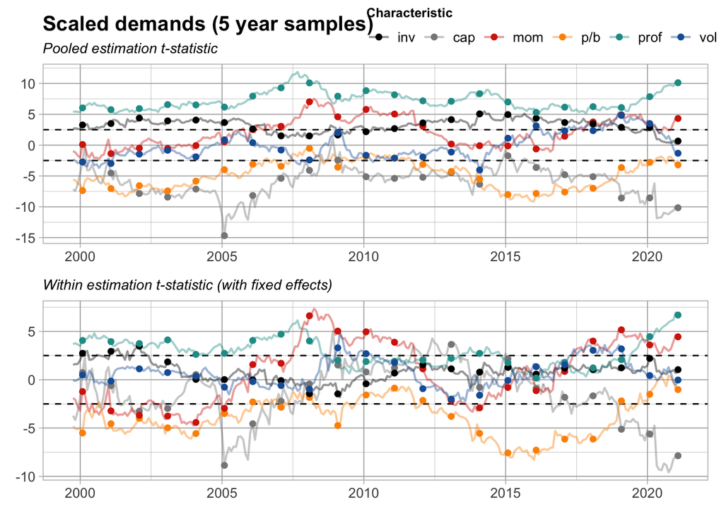

```r
data_graph <- t_stats_1_l
g1 <- data_graph %>%
  ggplot(aes(x = Date, y = D_Value, color = D_Factor)) + theme_light() +                       # Light theme
  geom_hline(yintercept = 2.5, linetype = 2) +                                                 # Upper 1% threshold
  geom_hline(yintercept = -2.5, linetype = 2) +                                                # Lower 1% threshold
  theme(legend.position = c(0.75,1.2),                                                         # Legend position
        text = element_text(size = 12),                                                        # Overall text size
        plot.title = element_text(face = "bold"),                                              # Bold title
        legend.title = element_text(face = "bold", size = 9),                                  # Title font size for the legend
        plot.subtitle = element_text(size = 10, face = "italic"),                              # Italic subtitle
        axis.title.x = element_blank(),                                                        # No x-axis title (obvious)
        axis.title.y = element_blank(),                                                        # No y-axis title (=title)
        panel.grid.major = element_line(size = 0.3, linetype = 'solid', colour = "#AAAAAA"),   # Grid adjustment
        panel.grid.minor = element_line(size = 0.1, linetype = 'solid', colour = "#AAAAAA")) + # Grid adjustment
  geom_line(alpha = 0.42, size = 0.7) + labs(subtitle = "Pooled estimation t-statistic") +     # Lines + subtitle
  geom_point(data = data_graph %>% filter(month(Date) == 1), size = 1.6) +                     # Points
  scale_color_manual(values = c("#000000", "#888888", "#D5280C", "#FC9203", "#219B96", "#185FA5", "#7D50D6"),
                     labels = c("inv", "cap", "mom", "p/b", "prof", "vol"), name = "Characteristic") +
  ggtitle("Scaled demands (5 year samples)") +
  guides(colour = guide_legend(nrow = 1))

data_graph <- t_stats_1_p_l
g2 <- data_graph %>%
  ggplot(aes(x = Date, y = D_Value, color = D_Factor)) + theme_light() +
  geom_hline(yintercept = 2.5, linetype = 2) +
  geom_hline(yintercept = -2.5, linetype = 2) +
  theme(legend.position = "none",
        text = element_text(size = 12),
        plot.title = element_text(face = "bold"),
        legend.title = element_text(face = "bold", size = 9),
        plot.subtitle = element_text(size = 10, face = "italic"),
        axis.title.x = element_blank(),
        axis.title.y = element_blank(),
        panel.grid.major = element_line(size = 0.3, linetype = 'solid', colour = "#AAAAAA"),
        panel.grid.minor = element_line(size = 0.1, linetype = 'solid', colour = "#AAAAAA")) +
  geom_line(alpha = 0.42, size = 0.7) +  labs(subtitle = "Within estimation t-statistic (with fixed effects)") +
  geom_point(data = data_graph %>% filter(month(Date) == 1), size = 1.6) +
  scale_color_manual(values = c("#000000", "#888888", "#D5280C", "#FC9203", "#219B96", "#185FA5", "#7D50D6"),
                     labels = c("inv", "cap", "mom", "p/b", "prof", "vol"), name = "Characteristic") #+
g1/g2
```

# 4 Graph of fixed effects & R^2

We are then interested in the distribution of fixed effects and the dynamics of the R^2.

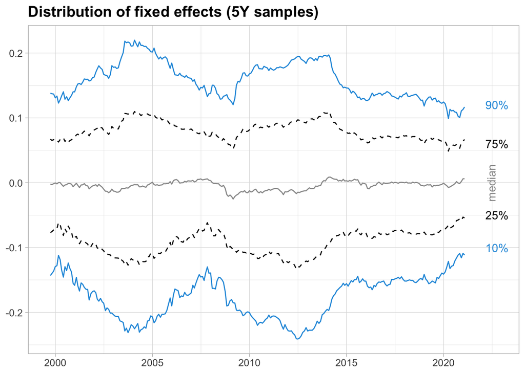

```r
f1 <- f_e %>%
  group_by(Date) %>%
  summarize(avg_fe = median(f_e),
            fe_90 = quantile(f_e, 0.9),
            fe_10 = quantile(f_e, 0.1),
            fe_25 = quantile(f_e, 0.25),
            fe_75 = quantile(f_e, 0.75)) %>%
  ggplot(aes(x = Date, y = avg_fe)) + geom_line(color = "#999999") +
  geom_line(aes(y = fe_90), color = "#2299DD") + geom_line(aes(y = fe_75), linetype = 2) +
  geom_line(aes(y = fe_10), color = "#2299DD") + geom_line(aes(y = fe_25), linetype = 2) +
  annotate("text", x = as.Date("2022-10-01"), y = 0.12, label = "90%", color = "#2299DD") +
  annotate("text", x = as.Date("2022-10-01"), y = 0.06, label = "75%") +
  annotate("text", x = as.Date("2022-06-21"), y = 0, label = "median", color = "#999999", angle = 90) +
  annotate("text", x = as.Date("2022-10-01"), y = -0.05, label = "25%") +
  annotate("text", x = as.Date("2022-10-01"), y = -0.1, label = "10%", color = "#2299DD") +
  theme_light() + ggtitle("Distribution of fixed effects (5Y samples)") +
  theme(axis.title.x = element_blank(),
        axis.title.y = element_blank(),
        text = element_text(size = 12),
        plot.title = element_text(face = "bold"),
        legend.title = element_text(face = "bold", size = 9))
f1
```

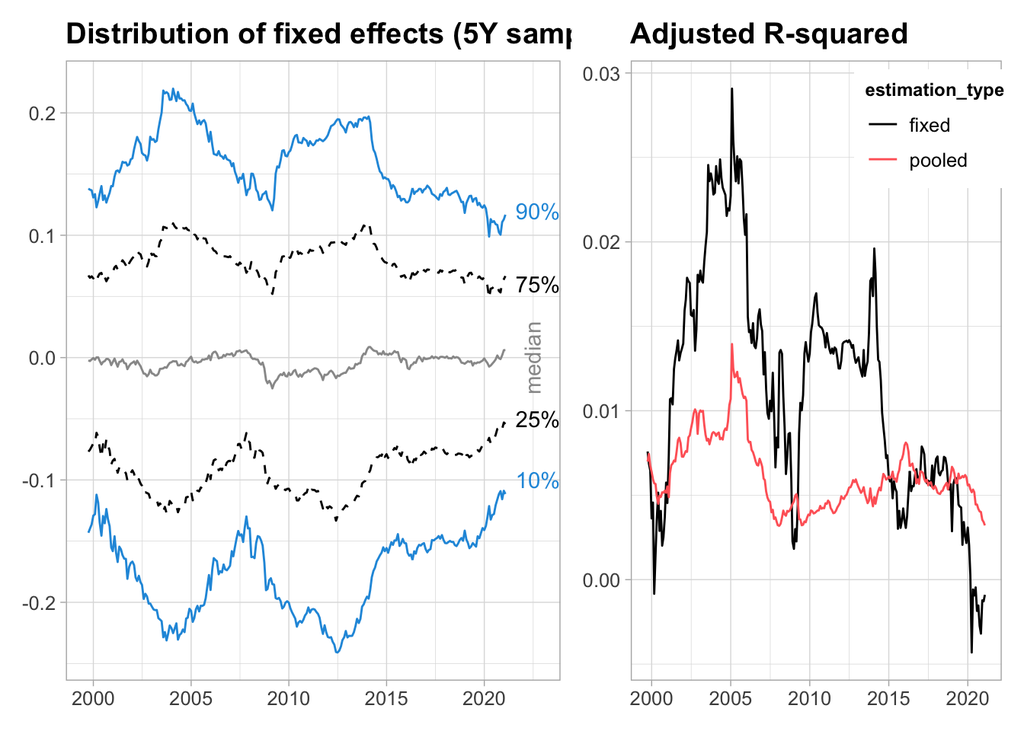

```r
r2 <- bind_cols(date = dates_oos[1:(length(dates_oos)-1)], R_1_pool, R_1_fixed)
colnames(r2) <- c("date", "pooled_R2", "pooled_Adj", "fixed_R2", "fixed_Adj")

f2 <- r2 %>%
  pivot_longer(-date, names_to = "estimation", values_to = "value") %>%
  separate(estimation, into = c("estimation_type", "R2_type"), sep = "_") %>%
  filter(R2_type == "Adj") %>%
  ggplot(aes(x = date, y = value, color = estimation_type )) + geom_line() + theme_light() +
  scale_color_manual(values = c("#000000", "#FF6666")) + ggtitle("Adjusted R-squared") +
  theme(axis.title.x = element_blank(),
        axis.title.y = element_blank(),
        legend.position = c(0.82,0.89),
        text = element_text(size = 12),
        plot.title = element_text(face = "bold"),
        legend.title = element_text(face = "bold", size = 9))

f1 + f2 +  plot_layout(widths = c(8, 6))
```

# 5 Anomaly decomposition

In the paper, we decompose the average return of sorted portfolios into three terms:  
1. the average fixed effect (not explained by characteristics)  
2. the loading on the characteristic of the sort  
3. interaction terms

Below, we compute the first two, along with average returns for each rolling window.  
The grey curve is equal to the average return minus the first two terms.

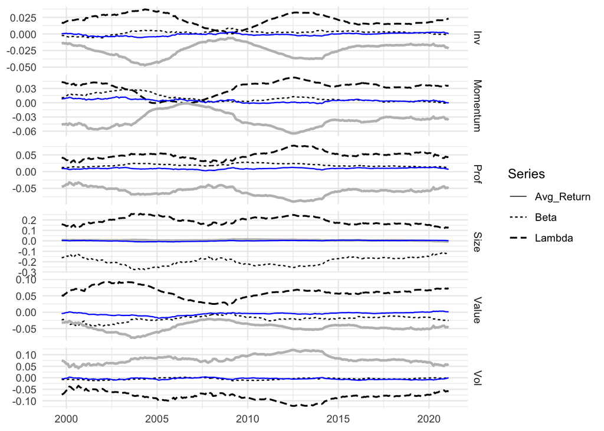

```r
avg_exp <- bind_rows(   # This long expression concatenates the indicators:
  # The average returns
  avg_ret %>%
    `colnames<-` (c("Size", "Value", "Momentum", "Inv", "Prof", "Vol")) %>%
    data.frame() %>%
    bind_cols(data.frame(Date = dates_oos[1:(length(dates_oos)-1)])) %>%
    pivot_longer(-Date, names_to = "Factor", values_to = "value") %>%
    mutate(Series = "Avg_Return"),
  # The coefficients
  bind_cols(Date = dates_oos[1:(length(dates_oos)-1)]) %>%
    data.frame(Size = coefs_1_p$Mkt_Cap,
               Value = coefs_1_p$P2B,
               Momentum = coefs_1_p$Mom,
               Inv = coefs_1_p$Asset_growth,
               Prof = coefs_1_p$Prof_Marg,
               Vol = coefs_1_p$Vol_1M) %>%
    pivot_longer(-Date, names_to = "Factor", values_to = "value") %>%
    mutate(Series = "Beta", value = value *4/sqrt(2*3.14)),
  # And the weighted average of fixed effects (for each sorted portfolio type)
  data.frame(Size = avg_fe[,1],
             Value = avg_fe[,2],
             Momentum = avg_fe[,3],
             Inv = avg_fe[,4],
             Prof = avg_fe[,5],
             Vol = avg_fe[,6]) %>%
    bind_cols(data.frame(Date = dates_oos[1:(length(dates_oos)-1)])) %>%
    pivot_longer(-Date, names_to = "Factor", values_to = "value") %>%
    mutate(Series = "Lambda")
)
avg_exp %>% # Then, we plot the series
  ggplot() + geom_line(aes(x = Date, y = value, linetype = Series, size = Series), color = "black") +
  scale_size_manual(values = c(0.3,0.5,0.7)) +  theme_minimal() +
  theme(axis.title.x = element_blank(),
        axis.title.y = element_blank()) +
  geom_line(data = avg_exp %>% # This is the second layer with the grey curve
              pivot_wider(names_from = Series, values_from = value) %>%
              mutate(Residual = Avg_Return - Beta - Lambda),
            aes(x = Date, y = Residual),
            color = "grey", size = 0.99) +
  geom_line(data = avg_exp %>% filter(Series == "Avg_Return" ),
            aes(x = Date, y = value),
            color = "blue", size = 0.5) +
  facet_grid(rows = vars(Factor), scales = "free")
```

# 6 The dispersion of sample means

The graph below shows that, as sample size increases, the dispersion of sample means decreases.  
We compare 12 month versus 60 month samples.

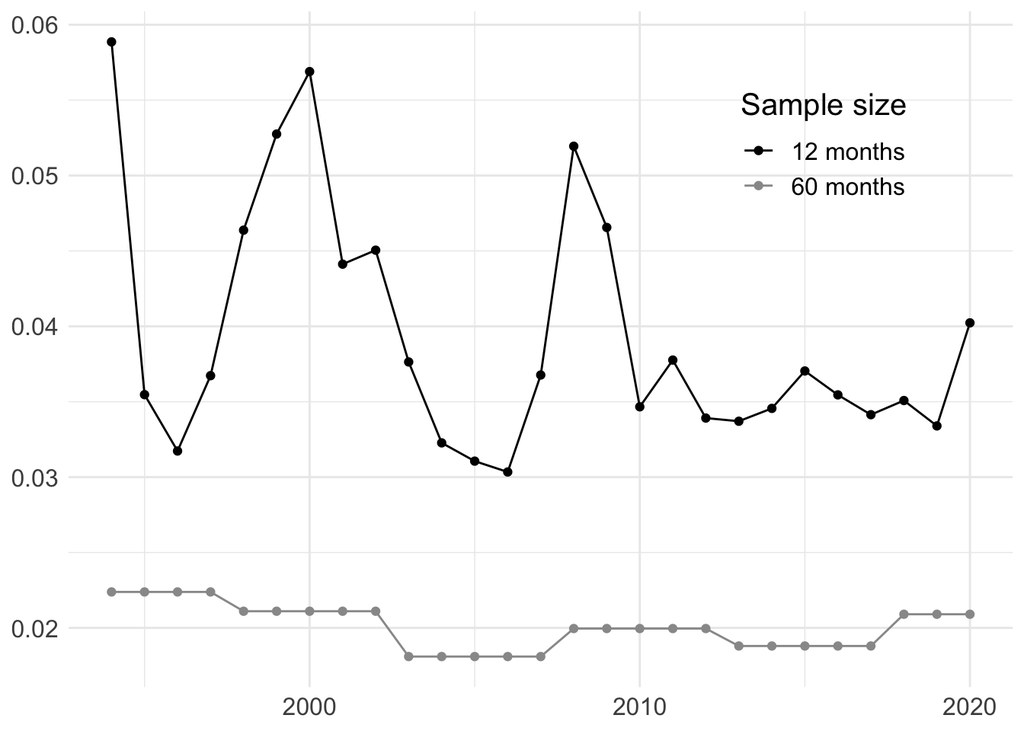

```r
disp_sample <- data_demand %>%
  mutate(year = year(Date),
         half_dec = round(year(Date)/5)) %>%
  group_by(year, Stock_id) %>%
  mutate(avg_12 = mean(Return, na.rm = T)) %>%  # Average 12 month returns
  ungroup() %>%
  group_by(year) %>%
  mutate(sd_12 = sd(avg_12, na.rm = T)) %>%     # Dispersion in avg 12m returns
  ungroup() %>%
  group_by(half_dec, Stock_id) %>%
  mutate(avg_60 = mean(Return, na.rm = T)) %>%  # Average 60 month returns
  ungroup() %>%
  group_by(half_dec) %>%
  mutate(sd_60 = sd(avg_60)) %>%                # Dispersion in avg 60m returns
  ungroup() %>%
  pivot_longer(cols = c("sd_12", "sd_60"), names_to = "type", values_to = "value")

disp_sample_light <- disp_sample[!duplicated(disp_sample %>% select(year, type, value)),] # Remove duplicates

disp_sample_light %>%                           # Plot
  filter(year < 2021) %>%
  ggplot(aes(x = year, y = value, color = type)) + geom_line() +
  geom_point() + theme_minimal() +
  scale_color_manual(name = "Sample size", values = c("#000000", "#999999"), labels = c("12 months", "60 months")) +
  theme(legend.position = c(0.8,0.8),
        text = element_text(size = 15),
        axis.title.x = element_blank(),
        axis.title.y = element_blank())
```

```r
#ggsave("disp_sample.pdf", width = 8, height = 4)
```